# MGT 599 Capstone - Group 4

## Descriptive Analytics

April 2026

This notebook goes through both datasets and looks at the data in detail - shapes, missing values, class distributions, revenue numbers, text lengths, word frequencies, and correlations.

## Setup

```python
import sys
import re
import warnings
from pathlib import Path
from collections import Counter

import pandas as pd
import numpy as np
import matplotlib.pyplot as plt
import seaborn as sns

warnings.filterwarnings('ignore')

PROJECT_ROOT = Path.cwd().parent if Path.cwd().name == 'notebooks' else Path.cwd()
sys.path.insert(0, str(PROJECT_ROOT / 'scripts'))
sys.path.insert(0, str(PROJECT_ROOT))

from common_utils import (
    CLEANED_PATH, ensure_folders,
    load_task_dataframe, guess_target_column,
    guess_text_columns, safe_text, set_chart_style
)

set_chart_style()
ensure_folders()
print('ready')
```

```
ready
```

## 1. Dataset overview

```python
task1 = load_task_dataframe('task1')
task2 = load_task_dataframe('task2')

t1_target = guess_target_column(task1, 'task1')
t2_target = guess_target_column(task2, 'task2')
t1_text_cols = guess_text_columns(task1)
t2_text_cols = guess_text_columns(task2)

print('task 1')
print(f'  rows: {task1.shape[0]:,}  cols: {task1.shape[1]}')
print(f'  target: {t1_target}  classes: {task1[t1_target].nunique()}')
print()
print('task 2')
print(f'  rows: {task2.shape[0]:,}  cols: {task2.shape[1]}')
print(f'  target: {t2_target}  classes: {task2[t2_target].nunique()}')
```

```
Loading task1 from: C:\Users\akash\Desktop\capstone MGT 599\data\cleaned\task1_clean.csv
```

```
Loaded! Shape: (53585, 10)
Loading task2 from: C:\Users\akash\Desktop\capstone MGT 599\data\cleaned\task2_clean.csv
Loaded! Shape: (27537, 5)
Guessed target column for task1: MstarGlobal
Guessed target column for task2: Subindustry
task 1
  rows: 53,585  cols: 10
  target: MstarGlobal  classes: 145

task 2
  rows: 27,537  cols: 5
  target: Subindustry  classes: 428
```

```python
print('task 1 column types:')
display(task1.dtypes.rename('dtype').to_frame())
print('\ntask 2 column types:')
display(task2.dtypes.rename('dtype').to_frame())
```

```
task 1 column types:
```

|  | dtype |
| --- | --- |
| CompanyId | str |
| AsOfDate | str |
| LongProfile | str |
| SegmentName | str |
| SegmentDescription | str |
| Revenue | float64 |
| total_revenue_company_as_of | float64 |
| revenue_share | float64 |
| is_largest_share_segment | bool |
| MstarGlobal | int64 |

```
task 2 column types:
```

|  | dtype |
| --- | --- |
| CompanyId | str |
| AsOfDate | str |
| SegmentName | str |
| SegmentDescription | str |
| Subindustry | int64 |

```python
print('task 1 numeric stats:')
display(task1.describe().T.round(2))
```

```
task 1 numeric stats:
```

|  | count | mean | std | min | 25% | 50% | 75% | max |
| --- | --- | --- | --- | --- | --- | --- | --- | --- |
| Revenue | 53585.0 | 6.983377e+13 | 1.046236e+16 | -4.139714e+12 | 6.591468e+07 | 6.990010e+08 | 7.045047e+09 | 1.796362e+18 |
| total_revenue_company_as_of | 53585.0 | 2.097876e+14 | 2.784890e+16 | -4.376729e+09 | 3.650180e+08 | 3.435000e+09 | 3.272200e+10 | 3.722006e+18 |
| revenue_share | 53585.0 | 4.300000e-01 | 8.400000e-01 | -1.071800e+02 | 8.000000e-02 | 3.100000e-01 | 8.600000e-01 | 1.071800e+02 |
| MstarGlobal | 53585.0 | 2.043733e+07 | 9.381774e+06 | 1.011001e+07 | 1.032002e+07 | 2.061001e+07 | 3.103001e+07 | 3.113003e+07 |

```python
print('task 2 numeric stats:')
display(task2.describe().T.round(2))
```

```
task 2 numeric stats:
```

|  | count | mean | std | min | 25% | 50% | 75% | max |
| --- | --- | --- | --- | --- | --- | --- | --- | --- |
| Subindustry | 27537.0 | 2.065749e+09 | 9.518974e+08 | 1.011001e+09 | 1.032002e+09 | 2.062002e+09 | 3.103001e+09 | 3.113003e+09 |

## 2. Missing values and data quality

```python
def missing_report(df, name):
    report = pd.DataFrame({
        'column':          df.columns,
        'missing count':   [df[c].isna().sum() for c in df.columns],
        'missing %':       [round(df[c].isna().mean() * 100, 2) for c in df.columns],
        'unique values':   [df[c].nunique() for c in df.columns],
        'dtype':           [str(df[c].dtype) for c in df.columns],
    }).sort_values('missing count', ascending=False).reset_index(drop=True)
    print(f'{name}:')
    display(report)
    print(f'  duplicate rows: {df.duplicated().sum()}')

missing_report(task1, 'task 1')
missing_report(task2, 'task 2')
```

```
task 1:
```

|  | column | missing count | missing % | unique values | dtype |
| --- | --- | --- | --- | --- | --- |
| 0 | SegmentDescription | 27524 | 51.37 | 25695 | str |
| 1 | CompanyId | 0 | 0.00 | 23207 | str |
| 2 | AsOfDate | 0 | 0.00 | 55 | str |
| 3 | LongProfile | 0 | 0.00 | 23172 | str |
| 4 | SegmentName | 0 | 0.00 | 31325 | str |
| 5 | Revenue | 0 | 0.00 | 48602 | float64 |
| 6 | total_revenue_company_as_of | 0 | 0.00 | 22621 | float64 |
| 7 | revenue_share | 0 | 0.00 | 41479 | float64 |
| 8 | is_largest_share_segment | 0 | 0.00 | 2 | bool |
| 9 | MstarGlobal | 0 | 0.00 | 145 | int64 |

```
  duplicate rows: 0
task 2:
```

|  | column | missing count | missing % | unique values | dtype |
| --- | --- | --- | --- | --- | --- |
| 0 | CompanyId | 0 | 0.0 | 9352 | str |
| 1 | AsOfDate | 0 | 0.0 | 50 | str |
| 2 | SegmentName | 0 | 0.0 | 17629 | str |
| 3 | SegmentDescription | 0 | 0.0 | 27430 | str |
| 4 | Subindustry | 0 | 0.0 | 428 | int64 |

```
  duplicate rows: 1
```

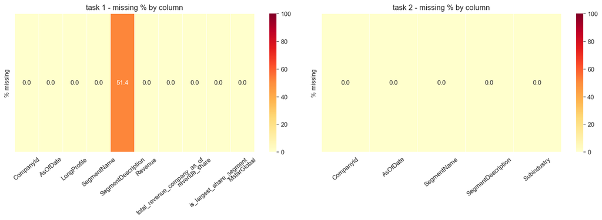

```python
fig, axes = plt.subplots(1, 2, figsize=(14, 5))

for ax, (df, name) in zip(axes, [(task1, 'task 1'), (task2, 'task 2')]):
    pct = (df.isna().mean() * 100).values.reshape(1, -1)
    sns.heatmap(
        pct, ax=ax,
        xticklabels=df.columns,
        yticklabels=['% missing'],
        cmap='YlOrRd', vmin=0, vmax=100,
        annot=True, fmt='.1f', linewidths=0.5
    )
    ax.set_title(f'{name} - missing % by column')
    ax.tick_params(axis='x', rotation=40)

plt.tight_layout()
plt.show()
```

## 3. Revenue analysis (task 1 numeric columns)

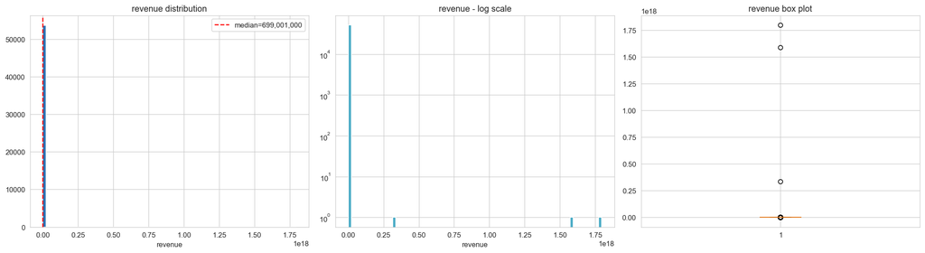

```
min: -4,139,714,000,000  max: 1,796,362,000,000,000,000
median: 699,001,000  mean: 69,833,765,106,802
zeros: 1,638  negatives: 354
```

```python
if 'Revenue' in task1.columns:
    rev = task1['Revenue'].dropna()

    fig, axes = plt.subplots(1, 3, figsize=(18, 5))

    axes[0].hist(rev, bins=80, color='#2E75B6', edgecolor='white')
    axes[0].set_title('revenue distribution')
    axes[0].set_xlabel('revenue')
    axes[0].axvline(rev.median(), color='red', linestyle='--',
                    label=f'median={rev.median():,.0f}')
    axes[0].legend()

    axes[1].hist(rev[rev > 0], bins=80, color='#4BACC6', edgecolor='white', log=True)
    axes[1].set_title('revenue - log scale')
    axes[1].set_xlabel('revenue')

    axes[2].boxplot(rev, patch_artist=True,
                    boxprops=dict(facecolor='#2E75B6', alpha=0.7))
    axes[2].set_title('revenue box plot')

    plt.tight_layout()
    plt.show()

    print(f'min: {rev.min():,.0f}  max: {rev.max():,.0f}')
    print(f'median: {rev.median():,.0f}  mean: {rev.mean():,.0f}')
    print(f'zeros: {(rev==0).sum():,}  negatives: {(rev<0).sum():,}')
```

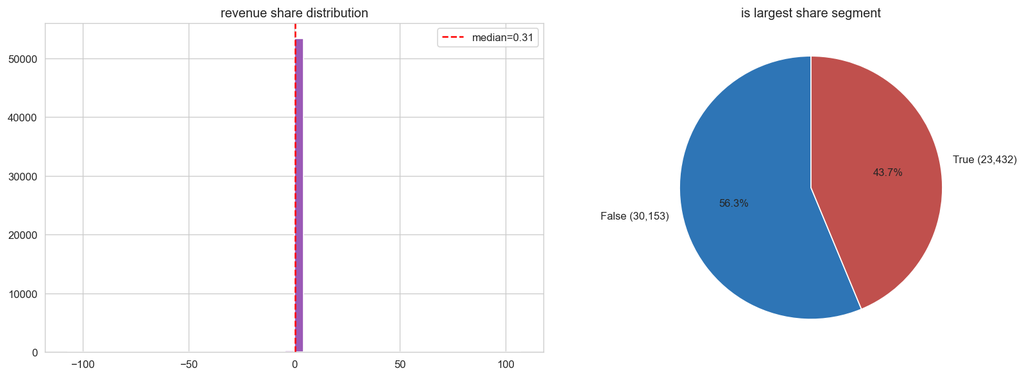

```python
if 'revenue_share' in task1.columns:
    rs = task1['revenue_share'].dropna()
    fig, axes = plt.subplots(1, 2, figsize=(14, 5))

    axes[0].hist(rs, bins=50, color='#9B59B6', edgecolor='white')
    axes[0].set_title('revenue share distribution')
    axes[0].axvline(rs.median(), color='red', linestyle='--',
                    label=f'median={rs.median():.2f}')
    axes[0].legend()

    if 'is_largest_share_segment' in task1.columns:
        vc = task1['is_largest_share_segment'].value_counts()
        axes[1].pie(vc.values, labels=[f'{k} ({v:,})' for k,v in vc.items()],
                    autopct='%1.1f%%', colors=['#2E75B6','#C0504D'], startangle=90)
        axes[1].set_title('is largest share segment')

    plt.tight_layout()
    plt.show()
```

## 4. Class distribution

```python
t1_vc = task1[t1_target].value_counts()

print('task 1 -', t1_target)
print(f'  total classes: {len(t1_vc)}')
print(f'  top class: {t1_vc.index[0]}  ({t1_vc.iloc[0]:,} records)')
print(f'  smallest: {t1_vc.index[-1]}  ({t1_vc.iloc[-1]:,} records)')
print(f'  classes with <10 rows: {(t1_vc<10).sum()}')
print(f'  top 3 classes cover: {t1_vc.head(3).sum()/len(task1)*100:.1f}% of data')
```

```
task 1 - MstarGlobal
  total classes: 145
  top class: 10310010  (2,359 records)
  smallest: 30920020  (28 records)
  classes with <10 rows: 0
  top 3 classes cover: 12.8% of data
```

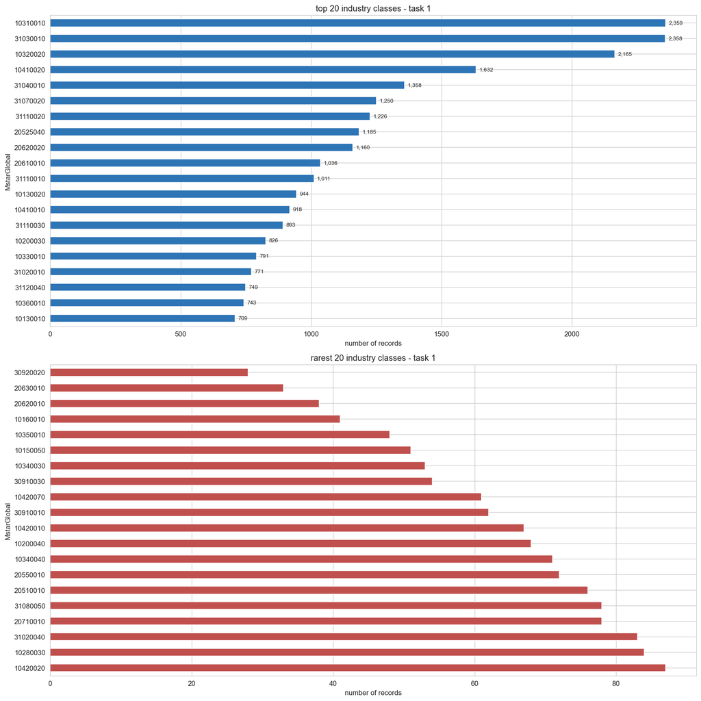

```python
fig, axes = plt.subplots(2, 1, figsize=(14, 14))

t1_vc.head(20).sort_values().plot(kind='barh', ax=axes[0], color='#2E75B6')
axes[0].set_title('top 20 industry classes - task 1')
axes[0].set_xlabel('number of records')
for i, v in enumerate(t1_vc.head(20).sort_values().values):
    axes[0].text(v + t1_vc.max()*0.005, i, f'{v:,}', va='center', fontsize=8)

t1_vc.tail(20).sort_values(ascending=False).plot(kind='barh', ax=axes[1], color='#C0504D')
axes[1].set_title('rarest 20 industry classes - task 1')
axes[1].set_xlabel('number of records')

plt.tight_layout()
plt.show()
```

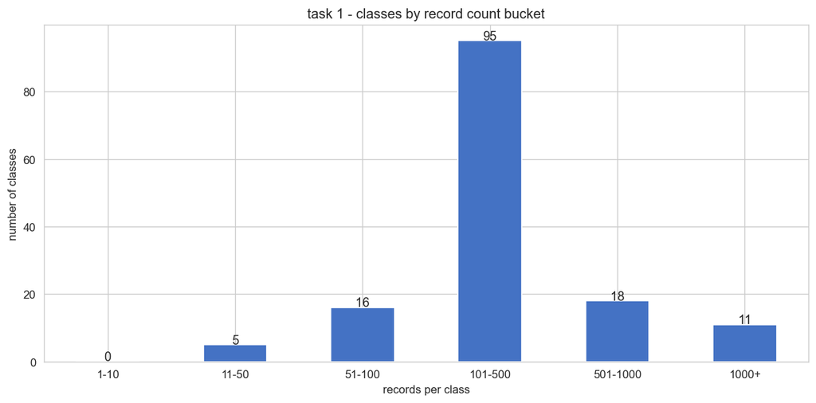

```python
buckets = pd.cut(t1_vc, bins=[0,10,50,100,500,1000,float('inf')],
                 labels=['1-10','11-50','51-100','101-500','501-1000','1000+'])
bc = buckets.value_counts().sort_index()

plt.figure(figsize=(10, 5))
bc.plot(kind='bar', color='#4472C4', edgecolor='white')
plt.title('task 1 - classes by record count bucket')
plt.xlabel('records per class')
plt.ylabel('number of classes')
plt.xticks(rotation=0)
for i, v in enumerate(bc.values):
    plt.text(i, v+0.3, str(v), ha='center', fontsize=11)
plt.tight_layout()
plt.show()
```

```python
t2_vc = task2[t2_target].value_counts()

print('task 2 -', t2_target)
print(f'  total classes: {len(t2_vc)}')
print(f'  top class: {t2_vc.index[0]}  ({t2_vc.iloc[0]:,} records)')
print(f'  smallest: {t2_vc.index[-1]}  ({t2_vc.iloc[-1]:,} records)')
print(f'  classes with <10 rows: {(t2_vc<10).sum()}')
print(f'  top 3 classes cover: {t2_vc.head(3).sum()/len(task2)*100:.1f}% of data')
```

```
task 2 - Subindustry
  total classes: 428
  top class: 3103001001  (2,018 records)
  smallest: 1014001003  (1 records)
  classes with <10 rows: 99
  top 3 classes cover: 12.1% of data
```

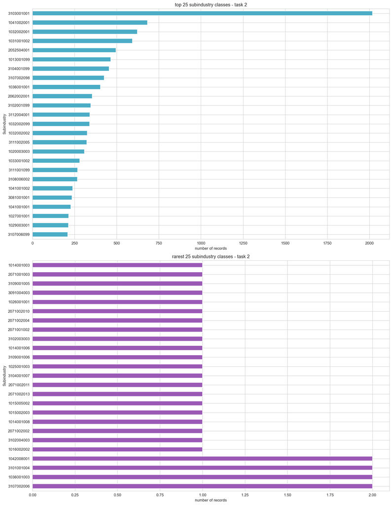

```python
fig, axes = plt.subplots(2, 1, figsize=(14, 18))

t2_vc.head(25).sort_values().plot(kind='barh', ax=axes[0], color='#4BACC6')
axes[0].set_title('top 25 subindustry classes - task 2')
axes[0].set_xlabel('number of records')

t2_vc.tail(25).sort_values(ascending=False).plot(kind='barh', ax=axes[1], color='#9B59B6')
axes[1].set_title('rarest 25 subindustry classes - task 2')
axes[1].set_xlabel('number of records')

plt.tight_layout()
plt.show()
```

## 5. Text column analysis

```python
def text_stats(df, col, label):
    txt = safe_text(df[col])
    char_len = txt.apply(len)
    word_cnt = txt.apply(lambda x: len(x.split()))
    empty = (txt.str.strip() == '').sum()
    short = (word_cnt < 5).sum()
    return pd.DataFrame([{
        'dataset':    label,
        'column':     col,
        'empty rows': empty,
        'empty %':    round(empty/len(df)*100, 1),
        'short (<5w)':short,
        'short %':    round(short/len(df)*100, 1),
        'avg chars':  round(char_len.mean(), 0),
        'med chars':  round(char_len.median(), 0),
        'max chars':  char_len.max(),
        'avg words':  round(word_cnt.mean(), 1),
        'med words':  round(word_cnt.median(), 1),
    }])

text_summary = pd.concat(
    [text_stats(task1, col, 'task 1') for col in t1_text_cols] +
    [text_stats(task2, col, 'task 2') for col in t2_text_cols],
    ignore_index=True
)
display(text_summary)
```

|  | dataset | column | empty rows | empty % | short (<5w) | short % | avg chars | med chars | max chars | avg words | med words |
| --- | --- | --- | --- | --- | --- | --- | --- | --- | --- | --- | --- |
| 0 | task 1 | LongProfile | 0 | 0.0 | 0 | 0.0 | 514.0 | 529.0 | 812 | 72.2 | 74.0 |
| 1 | task 1 | SegmentDescription | 27524 | 51.4 | 27546 | 51.4 | 101.0 | 0.0 | 520 | 13.8 | 0.0 |
| 2 | task 1 | SegmentName | 0 | 0.0 | 46494 | 86.8 | 21.0 | 17.0 | 129 | 2.8 | 2.0 |
| 3 | task 2 | SegmentDescription | 0 | 0.0 | 23 | 0.1 | 209.0 | 170.0 | 520 | 28.4 | 23.0 |
| 4 | task 2 | SegmentName | 0 | 0.0 | 25038 | 90.9 | 19.0 | 17.0 | 100 | 2.5 | 2.0 |

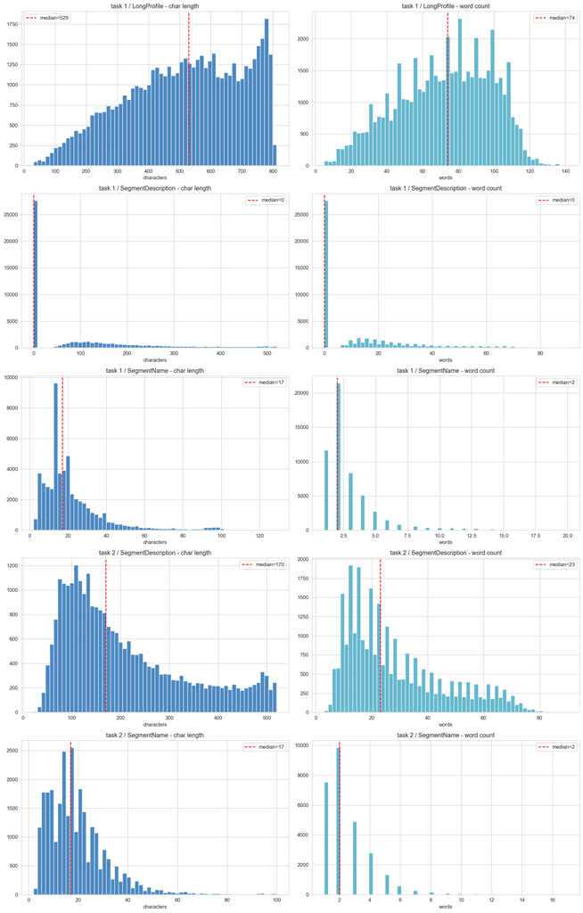

```python
all_pairs = [(task1, c, 'task 1') for c in t1_text_cols] + \
            [(task2, c, 'task 2') for c in t2_text_cols]

n = len(all_pairs)
if n > 0:
    fig, axes = plt.subplots(n, 2, figsize=(16, 5*n), squeeze=False)
    for i, (df, col, label) in enumerate(all_pairs):
        txt = safe_text(df[col])
        chars = txt.apply(len)
        words = txt.apply(lambda x: len(x.split()))

        axes[i][0].hist(chars, bins=60, color='#2E75B6', edgecolor='white', alpha=0.85)
        axes[i][0].axvline(chars.median(), color='red', linestyle='--',
                            label=f'median={chars.median():.0f}')
        axes[i][0].set_title(f'{label} / {col} - char length')
        axes[i][0].set_xlabel('characters')
        axes[i][0].legend()

        axes[i][1].hist(words, bins=60, color='#4BACC6', edgecolor='white', alpha=0.85)
        axes[i][1].axvline(words.median(), color='red', linestyle='--',
                            label=f'median={words.median():.0f}')
        axes[i][1].set_title(f'{label} / {col} - word count')
        axes[i][1].set_xlabel('words')
        axes[i][1].legend()

    plt.tight_layout()
    plt.show()
```

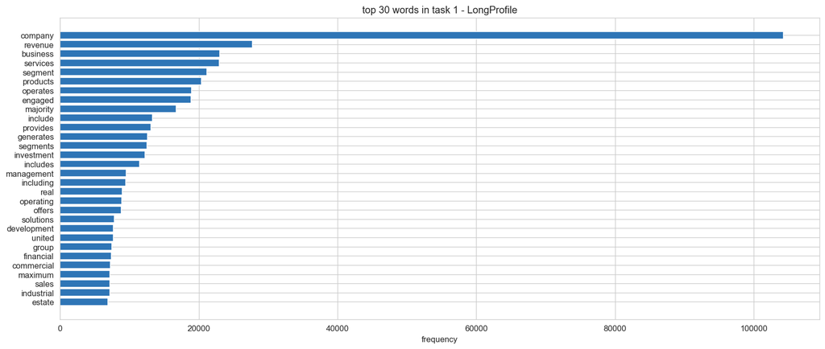

```python
STOPWORDS = {
    'the','and','of','a','in','to','is','that','for','with','its',
    'are','as','by','an','it','or','has','on','from','be','this','at',
    'which','was','have','also','their','more','been','than','but','all',
    'not','through','into','other','these','such','over','about','they',
    'we','our','can','will','well','who','based'
}

if t1_text_cols:
    all_words = ' '.join(safe_text(task1[t1_text_cols[0]]).str.lower()).split()
    filtered = [w for w in all_words
                if w not in STOPWORDS and len(w) > 2 and re.match(r'^[a-z]+$', w)]
    top30 = pd.DataFrame(Counter(filtered).most_common(30), columns=['word','count'])

    plt.figure(figsize=(14, 6))
    plt.barh(top30['word'][::-1], top30['count'][::-1], color='#2E75B6')
    plt.title(f'top 30 words in task 1 - {t1_text_cols[0]}')
    plt.xlabel('frequency')
    plt.tight_layout()
    plt.show()
```

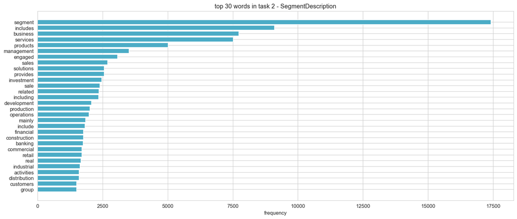

```python
if t2_text_cols:
    all_words2 = ' '.join(safe_text(task2[t2_text_cols[0]]).str.lower()).split()
    filtered2 = [w for w in all_words2
                 if w not in STOPWORDS and len(w) > 2 and re.match(r'^[a-z]+$', w)]
    top30_2 = pd.DataFrame(Counter(filtered2).most_common(30), columns=['word','count'])

    plt.figure(figsize=(14, 6))
    plt.barh(top30_2['word'][::-1], top30_2['count'][::-1], color='#4BACC6')
    plt.title(f'top 30 words in task 2 - {t2_text_cols[0]}')
    plt.xlabel('frequency')
    plt.tight_layout()
    plt.show()
```

## 6. Cross-analysis

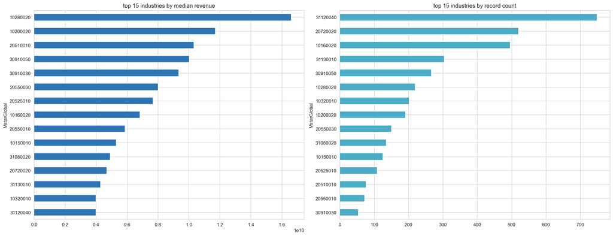

|  | MstarGlobal | median revenue | mean revenue | records |
| --- | --- | --- | --- | --- |
| 0 | 10280020 | 1.661248e+10 | 1.178089e+12 | 219 |
| 1 | 10200020 | 1.171200e+10 | 3.840234e+12 | 191 |
| 2 | 20510010 | 1.031500e+10 | 6.043847e+11 | 76 |
| 3 | 30910050 | 1.003585e+10 | 2.856332e+12 | 267 |
| 4 | 30910030 | 9.341000e+09 | 2.578516e+12 | 54 |
| 5 | 20550030 | 8.018400e+09 | 1.404971e+12 | 150 |
| 6 | 20525010 | 7.692490e+09 | 1.659368e+11 | 109 |
| 7 | 10160020 | 6.833839e+09 | 7.078970e+11 | 496 |
| 8 | 20550010 | 5.873802e+09 | 4.727995e+11 | 72 |
| 9 | 10150010 | 5.313788e+09 | 8.758536e+10 | 125 |

```python
if 'Revenue' in task1.columns:
    rev_by_ind = (
        task1.groupby(t1_target)['Revenue']
        .agg(['median','mean','count'])
        .rename(columns={'median':'median revenue','mean':'mean revenue','count':'records'})
        .sort_values('median revenue', ascending=False)
        .reset_index()
    )

    top15 = rev_by_ind.head(15)
    fig, axes = plt.subplots(1, 2, figsize=(18, 7))

    top15.sort_values('median revenue').plot(
        kind='barh', x=t1_target, y='median revenue', ax=axes[0], color='#2E75B6', legend=False
    )
    axes[0].set_title('top 15 industries by median revenue')

    top15.sort_values('records').plot(
        kind='barh', x=t1_target, y='records', ax=axes[1], color='#4BACC6', legend=False
    )
    axes[1].set_title('top 15 industries by record count')

    plt.tight_layout()
    plt.show()
    display(rev_by_ind.head(10).round(0))
```

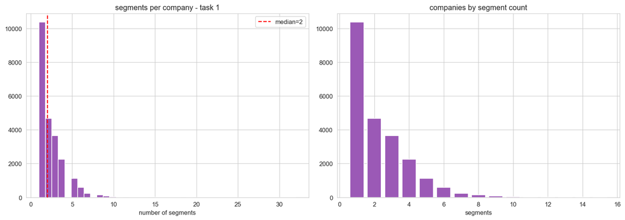

```
unique companies: 23,207
avg segments per company: 2.3
max segments: 32
single-segment companies: 10,364
```

```python
if 'CompanyId' in task1.columns:
    segs = task1.groupby('CompanyId').size()

    fig, axes = plt.subplots(1, 2, figsize=(14, 5))

    axes[0].hist(segs, bins=40, color='#9B59B6', edgecolor='white')
    axes[0].set_title('segments per company - task 1')
    axes[0].set_xlabel('number of segments')
    axes[0].axvline(segs.median(), color='red', linestyle='--',
                    label=f'median={segs.median():.0f}')
    axes[0].legend()

    vc = segs.value_counts().sort_index().head(15)
    axes[1].bar(vc.index, vc.values, color='#9B59B6', edgecolor='white')
    axes[1].set_title('companies by segment count')
    axes[1].set_xlabel('segments')

    plt.tight_layout()
    plt.show()

    print(f'unique companies: {segs.shape[0]:,}')
    print(f'avg segments per company: {segs.mean():.1f}')
    print(f'max segments: {segs.max()}')
    print(f'single-segment companies: {(segs==1).sum():,}')
```

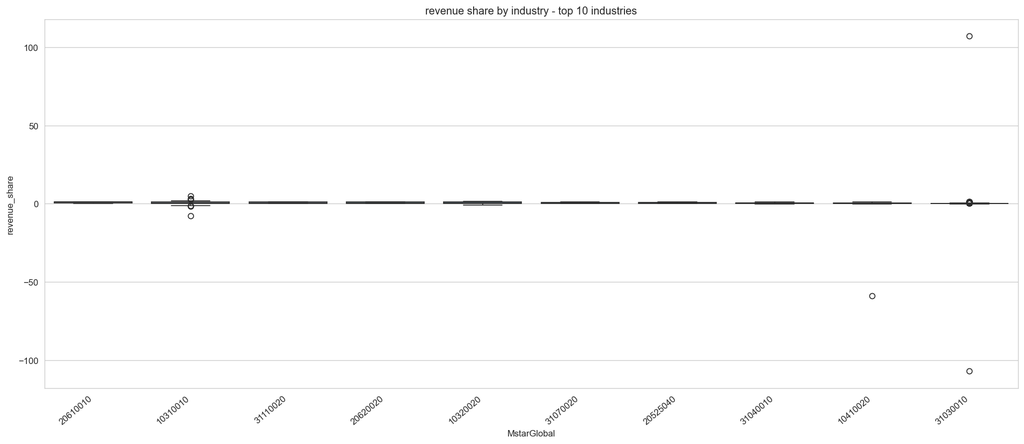

```python
if 'revenue_share' in task1.columns:
    top_ind = task1[t1_target].value_counts().head(10).index.tolist()
    subset = task1[task1[t1_target].isin(top_ind)]
    order = subset.groupby(t1_target)['revenue_share'].median().sort_values(ascending=False).index

    plt.figure(figsize=(16, 7))
    sns.boxplot(data=subset, x=t1_target, y='revenue_share', order=order, palette='Blues')
    plt.title('revenue share by industry - top 10 industries')
    plt.xticks(rotation=40, ha='right')
    plt.tight_layout()
    plt.show()
```

## 7. Correlation matrix

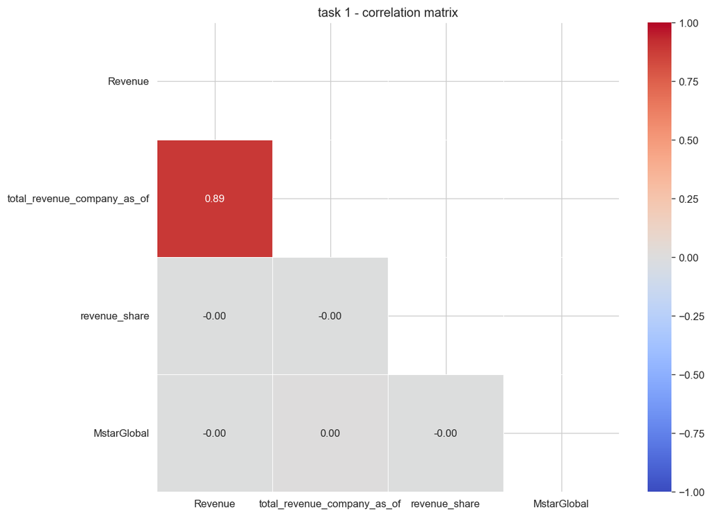

|  | Revenue | total_revenue_company_as_of | revenue_share | MstarGlobal |
| --- | --- | --- | --- | --- |
| Revenue | 1.000 | 0.887 | -0.000 | -0.003 |
| total_revenue_company_as_of | 0.887 | 1.000 | -0.001 | 0.000 |
| revenue_share | -0.000 | -0.001 | 1.000 | -0.004 |
| MstarGlobal | -0.003 | 0.000 | -0.004 | 1.000 |

```python
num_cols = task1.select_dtypes(include='number').columns.tolist()

if len(num_cols) >= 2:
    corr = task1[num_cols].corr()
    mask = np.triu(np.ones_like(corr, dtype=bool))

    plt.figure(figsize=(10, 7))
    sns.heatmap(corr, mask=mask, annot=True, fmt='.2f',
                cmap='coolwarm', center=0, linewidths=0.5, vmin=-1, vmax=1)
    plt.title('task 1 - correlation matrix')
    plt.tight_layout()
    plt.show()

    display(corr.round(3))
```

## 8. Full descriptive stats

```python
print('task 1:')
display(task1.describe(include='all').T.rename(columns={'50%':'median'}).round(2))
```

```
task 1:
```

|  | count | unique | top | freq | mean | std | min | 25% | median | 75% | max |
| --- | --- | --- | --- | --- | --- | --- | --- | --- | --- | --- | --- |
| CompanyId | 53585 | 23207 | EDKTSOEFOT | 32 | NaN | NaN | NaN | NaN | NaN | NaN | NaN |
| AsOfDate | 53585 | 55 | 2024-12-31 | 36126 | NaN | NaN | NaN | NaN | NaN | NaN | NaN |
| LongProfile | 53585 | 23172 | The company is a science-based pharmaceutical ... | 32 | NaN | NaN | NaN | NaN | NaN | NaN | NaN |
| SegmentName | 53585 | 31325 | Single Segment | 3987 | NaN | NaN | NaN | NaN | NaN | NaN | NaN |
| SegmentDescription | 26061 | 25695 | Financial assets investments segment engages i... | 4 | NaN | NaN | NaN | NaN | NaN | NaN | NaN |
| Revenue | 53585.0 | NaN | NaN | NaN | 69833765106802.171875 | 10462363218857392.0 | -4139714000000.0 | 65914679.0 | 699001000.0 | 7045046681.6 | 1796362000000000000.0 |
| total_revenue_company_as_of | 53585.0 | NaN | NaN | NaN | 209787627148765.84375 | 27848904728005100.0 | -4376729000.0 | 365018000.0 | 3435000000.0 | 32722000000.0 | 3722006000000000000.0 |
| revenue_share | 53585.0 | NaN | NaN | NaN | 0.433088 | 0.841642 | -107.175403 | 0.0831 | 0.309435 | 0.85927 | 107.175403 |
| is_largest_share_segment | 53585 | 2 | False | 30153 | NaN | NaN | NaN | NaN | NaN | NaN | NaN |
| MstarGlobal | 53585.0 | NaN | NaN | NaN | 20437326.591957 | 9381774.354863 | 10110010.0 | 10320020.0 | 20610010.0 | 31030010.0 | 31130030.0 |

```python
print('task 2:')
display(task2.describe(include='all').T.rename(columns={'50%':'median'}).round(2))
```

```
task 2:
```

|  | count | unique | top | freq | mean | std | min | 25% | median | 75% | max |
| --- | --- | --- | --- | --- | --- | --- | --- | --- | --- | --- | --- |
| CompanyId | 27537 | 9352 | V7HLP6L3AQ | 16 | NaN | NaN | NaN | NaN | NaN | NaN | NaN |
| AsOfDate | 27537 | 50 | 2024-12-31 | 16655 | NaN | NaN | NaN | NaN | NaN | NaN | NaN |
| SegmentName | 27537 | 17629 | Others | 927 | NaN | NaN | NaN | NaN | NaN | NaN | NaN |
| SegmentDescription | 27537 | 27430 | China Power International Development Ltd is p... | 4 | NaN | NaN | NaN | NaN | NaN | NaN | NaN |
| Subindustry | 27537.0 | NaN | NaN | NaN | 2065748906.368413 | 951897429.934186 | 1011001001.0 | 1032002001.0 | 2062002001.0 | 3103001001.0 | 3113003001.0 |

## What we found

Class imbalance is the main issue. A few industry categories have thousands of rows but a lot of the smaller ones have fewer than 10. If we train a model without handling this it will just overfit on the big categories.

Revenue is heavily right-skewed. A small number of very large companies pull the mean way up. The median is more representative. Log transformation might help if we use revenue as a feature.

Some description fields are empty or very short. The model needs text to work with so those rows are flagged.

The data is at the segment level so one company can have many rows, one per business segment.

The word frequency charts show that the descriptions do have industry-specific vocabulary which is encouraging for TF-IDF-based features.